# Tabular data - Bivariate relationships III: Numerical-Numerical

## Numeric & Numeric data

The study of bivariate relationships among numerical variables is known as correlation analysis. The data we have been using has few numerical columns, but I will produce two by aggregating the original data by county:

```r
covidMA_county=aggregate(data=covidMA,cbind(deaths,cases)~County,mean)

# you have:
covidMA_county
```

```
##                 County     deaths      cases
## 1           Barnstable 0.93023256  53.569767
## 2            Berkshire 0.68894009  29.262673
## 3              Bristol 3.32407407 226.203704
## 4                Dukes 0.00000000   5.420930
## 5  Dukes and Nantucket 0.01372998   0.000000
## 6                Essex 3.48275862 304.655172
## 7             Franklin 0.16435185  12.136574
## 8              Hampden 2.39814815 185.763889
## 9            Hampshire 0.50346420  34.258661
## 10           Middlesex 4.83640553 435.470046
## 11           Nantucket 0.00000000   5.275862
## 12             Norfolk 2.19310345 178.036782
## 13            Plymouth 2.17741935 165.232719
## 14             Suffolk 2.15116279 272.086047
## 15           Worcester 3.55148741 264.718535
```

Remember that Dukes and Nantucket had few cases and deaths:

```r
# then
covidMA_county=covidMA_county[covidMA_county$deaths>0 & covidMA_county$cases>0,]
```

Once we have the data organized, the clear option is the scatterplot:

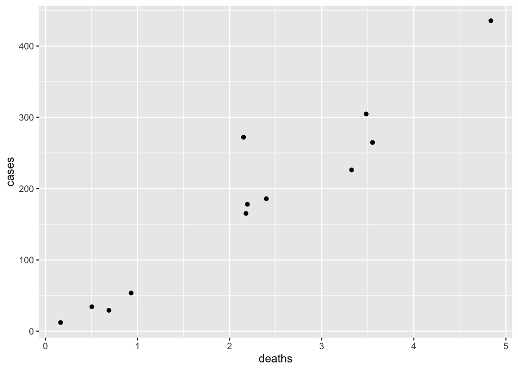

```r
base = ggplot(covidMA_county, aes(x=deaths,y=cases))
scat1= base +  geom_point()
scat1
```

If you compute the Pearson correlation coefficient, you may find a relevant correlation level:

```r
cor.test(covidMA_county$deaths,covidMA_county$cases,method = "pearson")
```

```
##
##  Pearson's product-moment correlation
##
## data:  covidMA_county$deaths and covidMA_county$cases
## t = 10.752, df = 10, p-value = 8.145e-07
## alternative hypothesis: true correlation is not equal to 0
## 95 percent confidence interval:
##  0.8577063 0.9888347
## sample estimates:
##      cor
## 0.959369
```

Let’s use **ggrepel** to show county names:

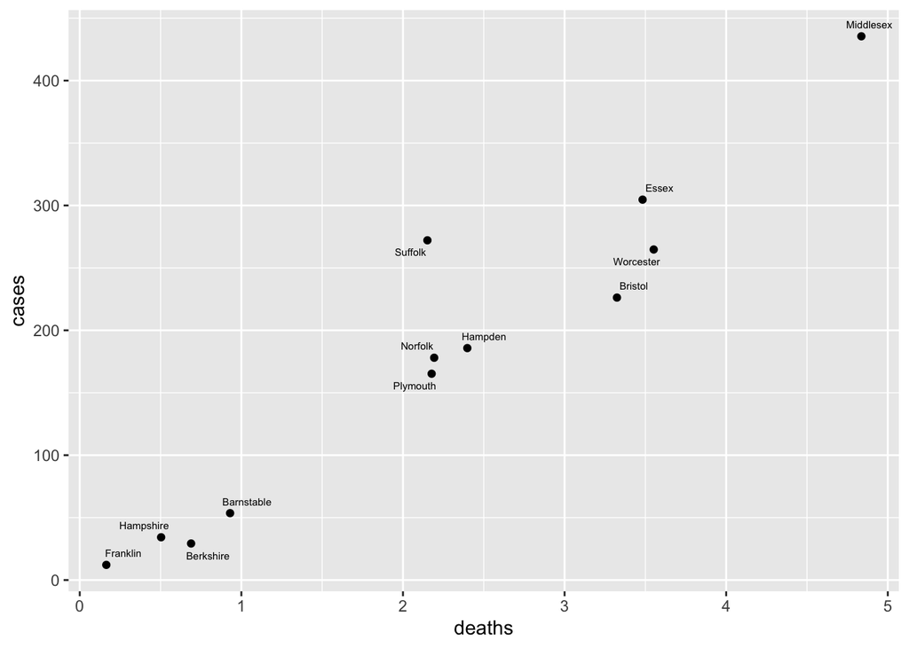

```r
library(ggrepel)
scat2=scat1 + geom_text_repel(aes(label=County),size=2)
scat2
```

Let’s highlight counts of counties around some values using hexagonal bins (install [hexbin](https://cran.r-project.org/web/packages/hexbin/index.html)):

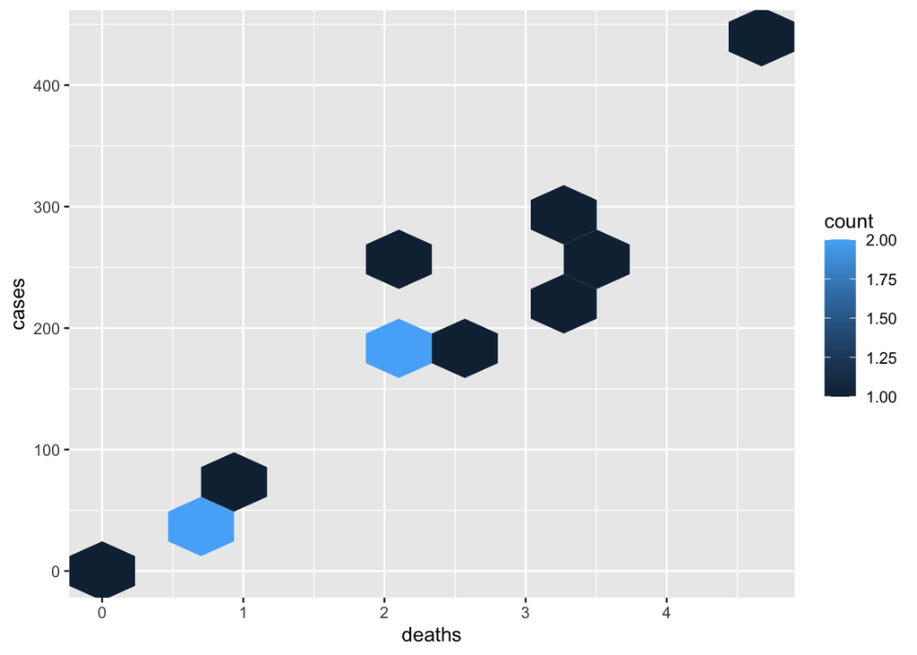

```r
base +  geom_hex(bins = 10)
```

Adding text:

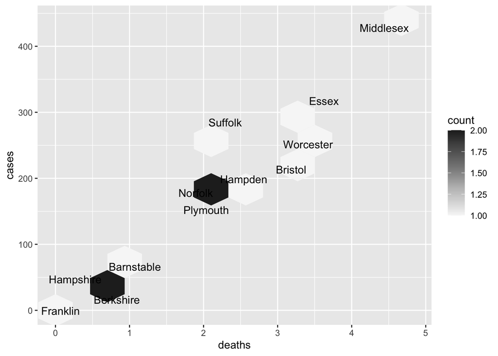

```r
scath = base +  geom_hex(bins = 10)

scath = scath + scale_fill_distiller(palette ="Greys",direction=1) +
        geom_text_repel(aes(label=County))
scath
```

The previous plot may need more work. An alternative could be a density plot (stat_density_2d):

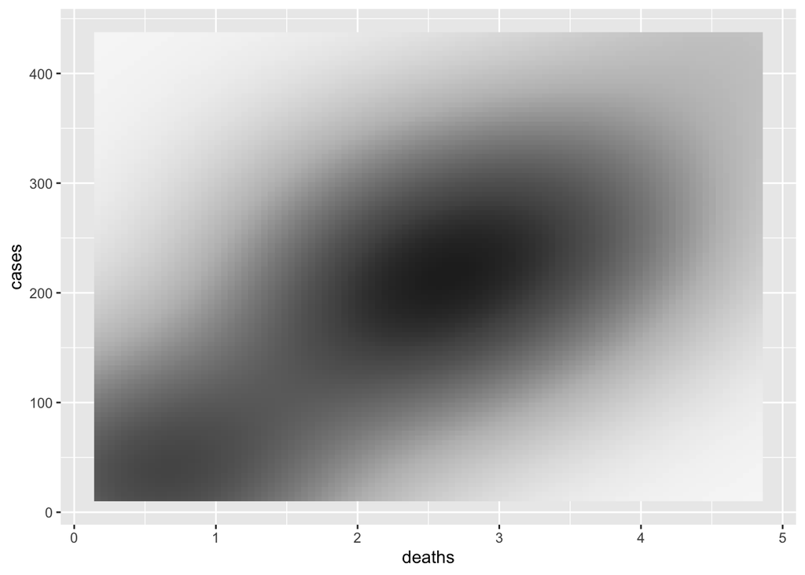

```r
base = ggplot(covidMA_county, aes(x=deaths,y=cases))

scatDens = base +  stat_density_2d(aes(fill = ..density..),
                                 geom = "raster", contour = FALSE,show.legend = F)

scatDens= scatDens + scale_fill_distiller(palette="Greys", direction=1)
scatDens
```

Notice that you still see the grid.Let’s add text and make the unneeded grid space:

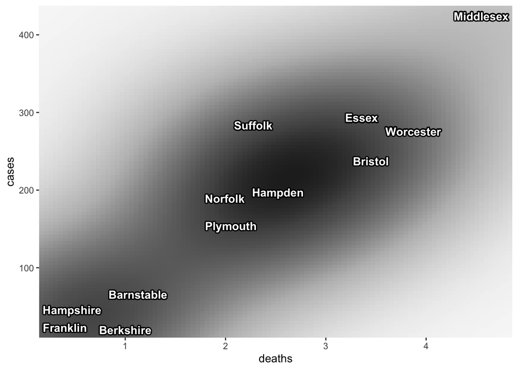

```r
scatDens1 = scatDens + geom_text_repel(aes(label=County),color='white',fontface='bold',bg.color = "black",bg.r = .15) +
    scale_y_continuous(expand = c(0, 0)) +
    scale_x_continuous(expand = c(0, 0))
scatDens1
```

Notice that some counties had cases below 100, and the rest above 100 but below 1000. The deaths cases averages were around values below 10. Then, what about highlighting that:

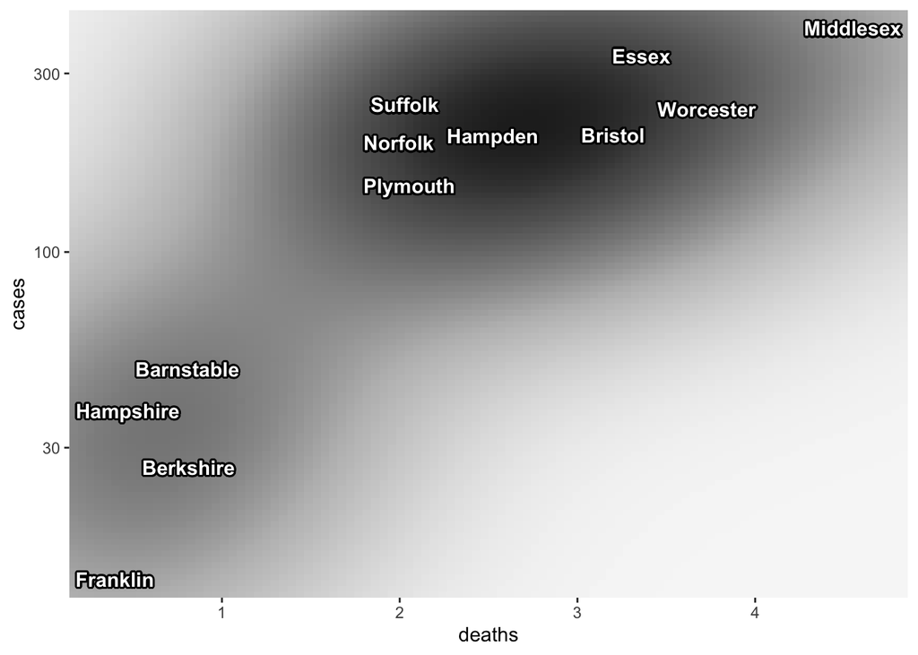

```r
scatDens1 = scatDens + geom_text_repel(aes(label=County),color='white',fontface='bold',bg.color = "black",bg.r = .15) +
    scale_y_continuous(expand = c(0, 0), transform = 'log10') +
    scale_x_continuous(expand = c(0, 0))
scatDens1
```

Finishing…

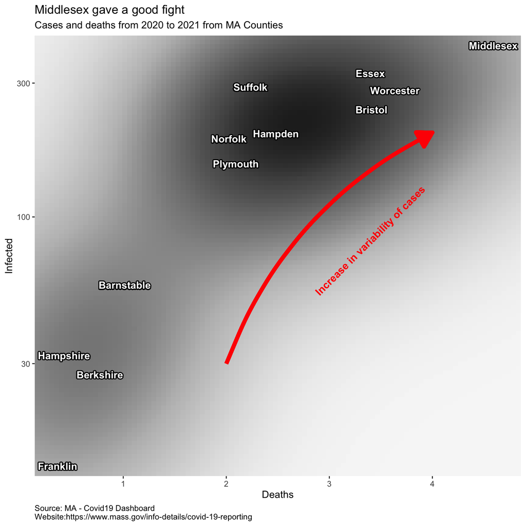

```r
# texts for labs
titleText="Middlesex gave a good fight"
sub_titleText="Cases and deaths from 2020 to 2021 from MA Counties"
captionText="Source: MA - Covid19 Dashboard \nWebsite:https://www.mass.gov/info-details/covid-19-reporting"
yText="Infected"
xText="Deaths"
colorLegendText=""

#####

scatDens1 + labs(title = titleText,
         subtitle = sub_titleText,
         caption = captionText,
         y=yText,
         x=xText,
         color=colorLegendText) + theme(plot.caption = element_text(hjust = 0)) +
         geom_curve(aes(x = 2, y = 30, xend = 4, yend = 200),
                      arrow = arrow(type = 'closed'),
                    size=2,
                    color='red',
                    curvature = -0.2) +
         annotate("text", x=3.5,y=90, label = "Increase in variability of cases",
                  color = "red",angle = 45, hjust = 0.6, size = 4, fontface = "bold")
```

Go to table of contents.

## Deliverable II (option 3)

Let me upload this file with information about Covid in the world:

```r
linkCovid="https://github.com/DACSS-Visual/tabular_bivar_numnum/raw/refs/heads/main/data/covid-19-cases-deaths-per-million-people.csv"

#see it
covidWorld=read.csv(linkCovid)
str(covidWorld)
```

```
## 'data.frame':    420322 obs. of  8 variables:
##  $ Entity           : chr  "Afghanistan" "Afghanistan" "Afghanistan" "Afghanistan" ...
##  $ date             : chr  "1/9/20" "1/10/20" "1/11/20" "1/12/20" ...
##  $ daily_cases_mean : num  0 0 0 0 0 0 0 0 0 0 ...
##  $ daily_deaths_mean: num  0 0 0 0 0 0 0 0 0 0 ...
##  $ day              : int  9 10 11 12 13 14 15 16 17 18 ...
##  $ month            : int  1 1 1 1 1 1 1 1 1 1 ...
##  $ year             : int  2020 2020 2020 2020 2020 2020 2020 2020 2020 2020 ...
##  $ week             : int  2 2 2 2 3 3 3 3 3 3 ...
```

Use the information on cases and deaths to produce a viz.

Go to table of contents.